# tidybayes

```r
library(tidyverse)
library(rstan)
library(tidybayes)
fit <- readRDS("1_fit.rds")
```

## tidy

```r
fit_tidy <- fit %>% spread_draws(tau, eta[r], theta[r], lp__)
fit_tidy %>% head
```

| .chain | .iteration | .draw | tau | r | eta | theta | lp__ |
| --- | --- | --- | --- | --- | --- | --- | --- |
| 1 | 1 | 1 | 9.978083 | 1 | 2.5431670 | 40.191648 | -40.1968 |
| 1 | 1 | 1 | 9.978083 | 2 | 0.2489800 | 17.300059 | -40.1968 |
| 1 | 1 | 1 | 9.978083 | 3 | -0.4634529 | 10.191345 | -40.1968 |
| 1 | 1 | 1 | 9.978083 | 4 | -0.5309981 | 9.517374 | -40.1968 |
| 1 | 1 | 1 | 9.978083 | 5 | 0.4216482 | 19.022957 | -40.1968 |
| 1 | 1 | 1 | 9.978083 | 6 | -0.5347387 | 9.480049 | -40.1968 |

配列のパラメータは、`eta[r]`などと指定する。

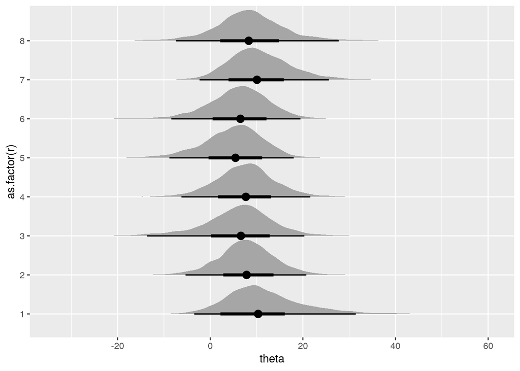

```r
fit_tidy %>%
  ggplot(aes(theta, as.factor(r))) +
  geom_halfeyeh(point_interval=median_hdci, # 中央値で点推定
                .width=c(.66,0.96)) # 66%確信区間・96%信頼区間（図の太線・細線）
```

median_hdciの他に、mean_hdci, mode_hdciもある。

これを値で取り出すには `point_interval`を使う

```r
point_interval(fit_tidy, .width=0.96, .point=median, .interval=hdci)
```

| r | tau | tau.lower | tau.upper | eta | eta.lower | eta.upper | theta | theta.lower | theta.upper | lp__ | lp__.lower | lp__.upper | .width | .point | .interval |
| --- | --- | --- | --- | --- | --- | --- | --- | --- | --- | --- | --- | --- | --- | --- | --- |
| 1 | 5.389348 | 0.003931741 | 18.35086 | 0.44048414 | -1.554573 | 2.272656 | 10.344662 | -3.461392 | 31.43009 | -39.06902 | -45.41009 | -34.48808 | 0.96 | median | hdci |
| 2 | 5.389348 | 0.003931741 | 18.35086 | -0.01615640 | -1.792206 | 1.767482 | 7.856054 | -5.333768 | 20.73398 | -39.06902 | -45.41009 | -34.48808 | 0.96 | median | hdci |
| 3 | 5.389348 | 0.003931741 | 18.35086 | -0.21019565 | -2.032676 | 1.666412 | 6.625055 | -13.666778 | 20.31440 | -39.06902 | -45.41009 | -34.48808 | 0.96 | median | hdci |
| 4 | 5.389348 | 0.003931741 | 18.35086 | -0.05326824 | -1.852630 | 1.712773 | 7.693725 | -6.210388 | 21.61206 | -39.06902 | -45.41009 | -34.48808 | 0.96 | median | hdci |
| 5 | 5.389348 | 0.003931741 | 18.35086 | -0.39265368 | -2.026026 | 1.598049 | 5.450893 | -8.824208 | 18.02478 | -39.06902 | -45.41009 | -34.48808 | 0.96 | median | hdci |
| 6 | 5.389348 | 0.003931741 | 18.35086 | -0.23212971 | -2.003102 | 1.651088 | 6.514276 | -8.408432 | 19.47570 | -39.06902 | -45.41009 | -34.48808 | 0.96 | median | hdci |
| 7 | 5.389348 | 0.003931741 | 18.35086 | 0.37249790 | -1.506182 | 2.175699 | 10.093269 | -2.306618 | 25.63535 | -39.06902 | -45.41009 | -34.48808 | 0.96 | median | hdci |
| 8 | 5.389348 | 0.003931741 | 18.35086 | 0.06689324 | -1.888881 | 1.982715 | 8.319825 | -7.388485 | 27.75308 | -39.06902 | -45.41009 | -34.48808 | 0.96 | median | hdci |

## itervalのバリエーション

`?point_interval` の内容をまとめる。 point_intervalは、確率分布からのサンプル系列から点推定、区間推定の結果を計算する。 .iterval引数の値としてqi, hdi, hdciが選べる

- qi：いわゆる普通のパーセンタイル
- hdi：分布が多峰型の場合に、複数の区間を返すかもしれない。
- hdci：分布が多峰型でも、単一の区間を返す。

多峰型のサンプルを作って実験してみる

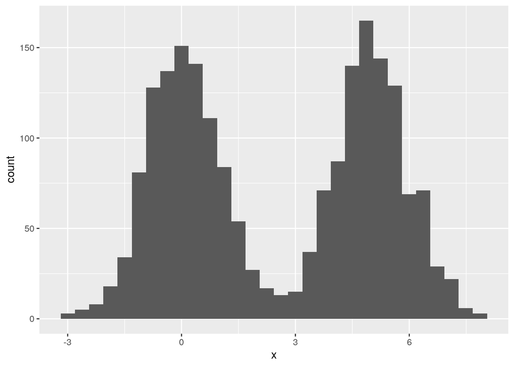

```r
x <- c(rnorm(1e3), rnorm(1e3, mean=5))
x %>% tibble(x=.) %>% ggplot(aes(x)) + geom_histogram()
```

### qi

```r
point_interval(x, .point = median, .interval = qi, .width = 0.95)
```

| y | ymin | ymax | .width | .point | .interval |
| --- | --- | --- | --- | --- | --- |
| 2.50313 | -1.509995 | 6.620137 | 0.95 | median | qi |

```r
quantile(x, c(0.025, 0.5, 0.975))
```

```
##      2.5%       50%     97.5%
## -1.509995  2.503130  6.620137
```

qiは、パーセンタールで間違いなさそう

### hdi

```r
point_interval(x, .point = median, .interval = hdi, .width = 0.95)
```

| y | ymin | ymax | .width | .point | .interval |
| --- | --- | --- | --- | --- | --- |
| 2.50313 | -1.940720 | 2.254324 | 0.95 | median | hdi |
| 2.50313 | 2.830114 | 7.079995 | 0.95 | median | hdi |

hdiの場合は、複数の区間が得られている。MCMCの結果を使う時には不都合かもね

### hdci

```r
point_interval(x, .point = median, .interval = hdci, .width = 0.95)
```

| y | ymin | ymax | .width | .point | .interval |
| --- | --- | --- | --- | --- | --- |
| 2.50313 | -1.433185 | 6.665835 | 0.95 | median | hdci |

hdciの場合は、区間は1個だけ。

qiの区間とhdciの区間は異なる。medianの値は、どの関数を使っても同じ。

モードで実験してみる。

```r
rbind(
  point_interval(x, .point = Mode, .interval = qi),
  point_interval(x, .point = Mode, .interval = hdi),
  point_interval(x, .point = Mode, .interval = hdci))
```

| y | ymin | ymax | .width | .point | .interval |
| --- | --- | --- | --- | --- | --- |
| 4.968764 | -1.509995 | 6.620137 | 0.95 | mode | qi |
| 4.968764 | -1.940720 | 2.254324 | 0.95 | mode | hdi |
| 4.968764 | 2.830114 | 7.079995 | 0.95 | mode | hdi |
| 4.968764 | -1.433185 | 6.665835 | 0.95 | mode | hdci |

モードでも点推定の結果は全部同じ。